# Data Visualization I

## Loess smoothed scatterplot with points of various sizes

- Scatterplot of highway miles per gallon on displacement
- Color points by car class
- Point size by city miles per gallon (cty)
- Large red loess line for all point and no confidence interval

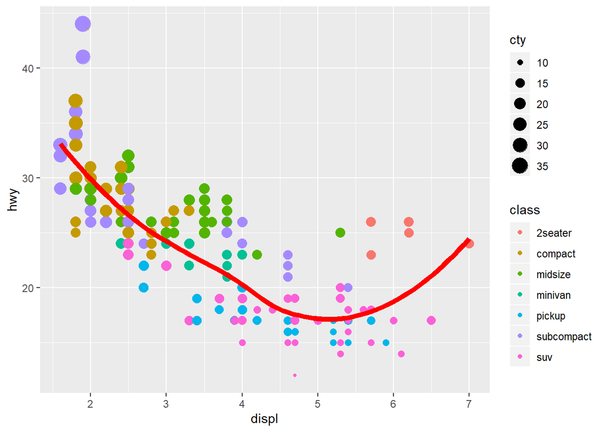

```r
ggplot(data = mpg, mapping = aes(x = displ, y = hwy)) +
  geom_point(mapping = aes(color = class, size = cty)) +
  geom_smooth(se = FALSE, size = 2, color = "red")
```

## Linear regression of highway on displacement

- Scatterplot of hwy on displ
- Color points by vehicle class
- Simple regression by vehicle class
- Show all points

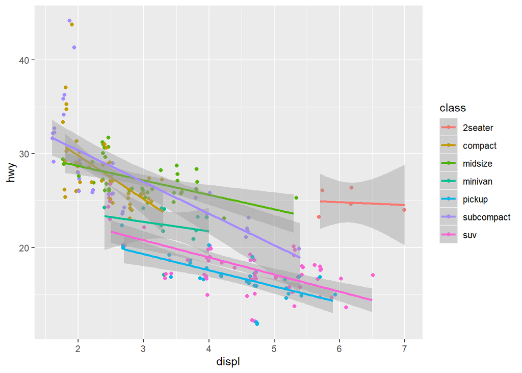

```r
ggplot(data = mpg, mapping = aes(x = displ, y = hwy, color = class)) +
  geom_point(position = "jitter") +
  geom_smooth(method = "lm")
```

## Linear regression of highway on displacement

- Scatterplot of hwy on displ
- Color by vehicle class
- Simple regression by vehicle class
- Each class has its own scatterplot
- Show all the points
- No Legend

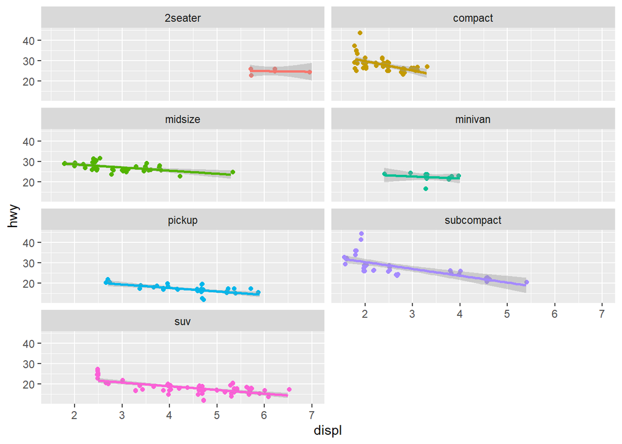

```r
ggplot(data = mpg, mapping = aes(x = displ, y = hwy, color = class)) +
  geom_point(position = "jitter", show.legend = FALSE) +
  geom_smooth(method = "lm", show.legend = FALSE) +
  facet_wrap(vars(class), ncol = 2)
```

## Linear regression of highway on displacement

- Scatterplot of hwy on displ
- Color by drivetrain type
- Simple regression (hwy on displacement) by drive train type and number of cylinders
- Draw a larger, black regression line
- Each drive train and number of cylinders has its own scatterplot
- Show all the points
- No Legend

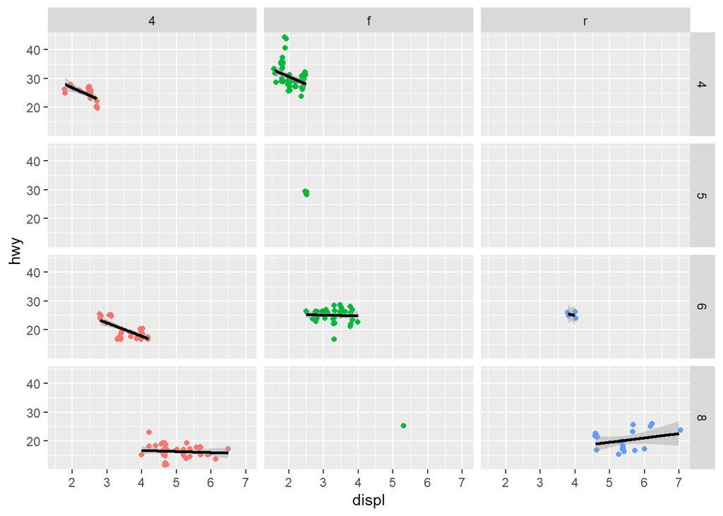

```r
ggplot(data = mpg, mapping = aes(x = displ, y = hwy, color = drv)) +
  geom_point(position = "jitter", show.legend = FALSE) +
  geom_smooth(method = "lm", show.legend = FALSE, color = "black", size = 1) +
  facet_grid(rows = vars(as.factor(cyl)), cols = vars(drv))
```

## Exercises from 3.6.1 Problem 6

### Simple smoothed scatterplot with blue line for smooth

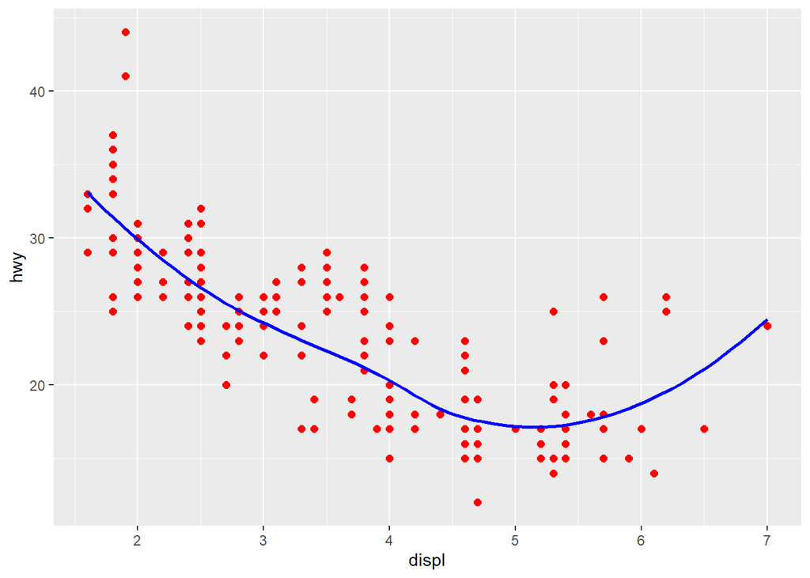

```r
ggplot(data = mpg, mapping = aes(x = displ, y = hwy)) +
  geom_point(color = "red", size = 2) +
  geom_smooth(color = "blue", se = FALSE)
```

### Smoothed scatterplot with blue smoothed line for each different drive train

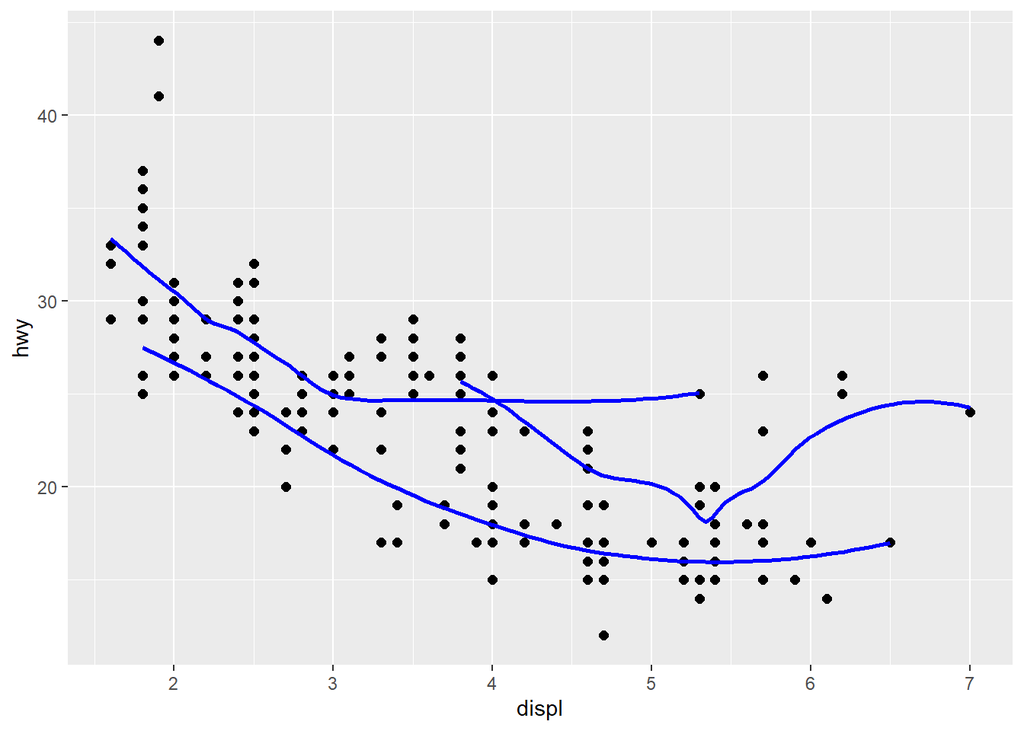

```r
ggplot(data = mpg,
       mapping = aes(x = displ, y = hwy, group = drv)) +
  geom_point(size = 2) +
  geom_smooth(color = "blue", se = FALSE)
```

### Smoothing and color by drive train

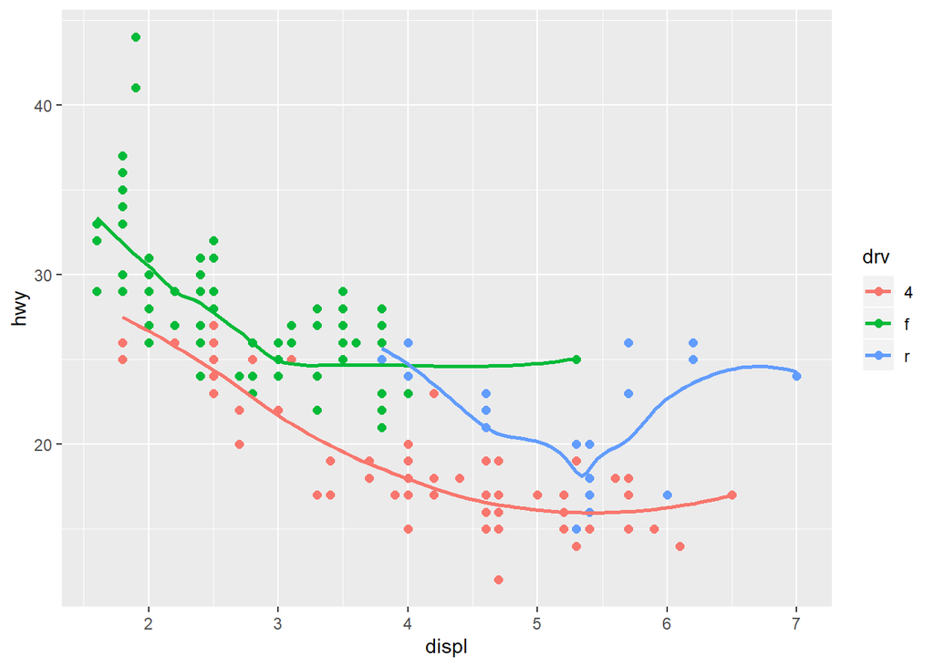

```r
ggplot(data = mpg,
       mapping = aes(x = displ, y = hwy, color = drv)) +
  geom_point(size = 2) +
  geom_smooth(se = FALSE)
```

### Color symbols by drive train but blue global smooth

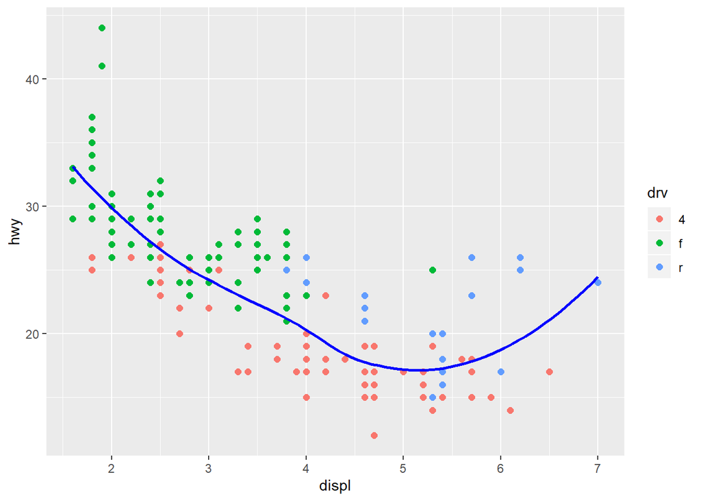

```r
ggplot(data = mpg,
       mapping = aes(x = displ, y = hwy, color = drv)) +
  geom_point(mapping = aes(color = drv), size = 2) +
  geom_smooth(se = FALSE, color = "blue")
```

### Symbols colored by drive train with smoothing by linetype

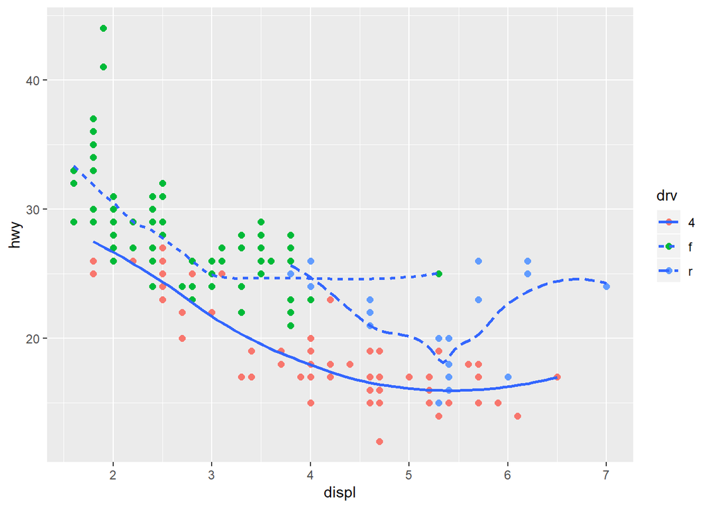

```r
ggplot(data = mpg, mapping = aes(x = displ, y = hwy)) +
  geom_point(mapping = aes(color = drv), size = 2) +
  geom_smooth(mapping = aes(linetype = drv), se = FALSE)
```

### Color in circles as the plotting symbols

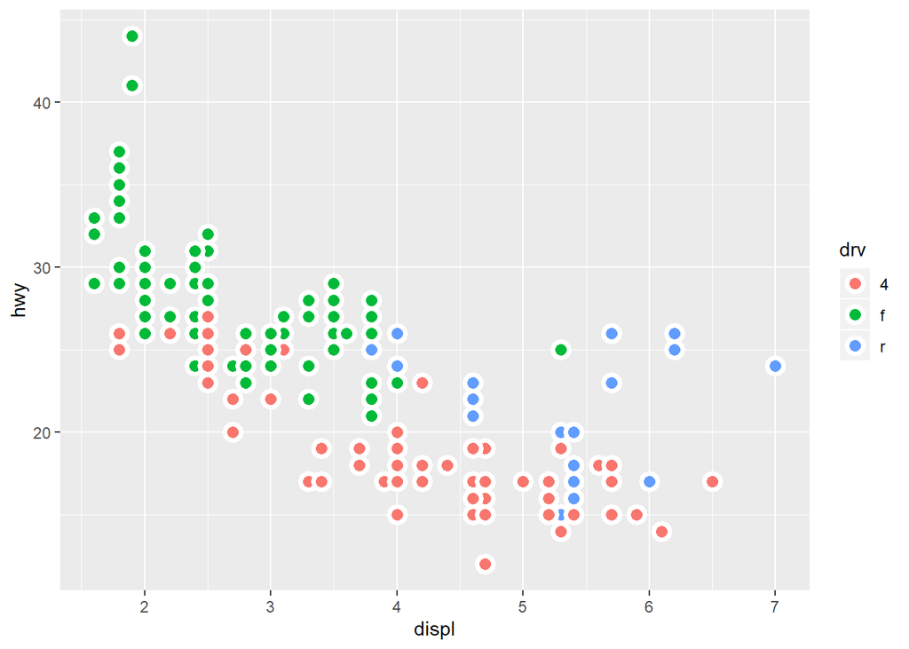

```r
ggplot(data = mpg, mapping = aes(x = displ, y = hwy, fill = drv)) +
  geom_point(
    size = 3,
    shape = 21,
    color = "white",
    stroke = 2
  )
```